# 24_1s_MTM1013T11_AP02_parteB_AndreGoncalvesdaSilva

#### MTM1013 - MÉT. NUM. E COMPUTACIONAIS Prof. Charles R. P. Szinvelski

### AP(02) - Parte A e B

#### 1s/UFSM Período: 12-19/08/24

#### Acadêmico: André Gonçalves da Silva Matrícula: 202210071 Curso/Turma: 123/11

As questões da Avaliação Parcial 02 (AP(02)) tem por finalidade a aplicação direta dos aspectos teóricos e práticos dos métodos numéricos abordados na disciplina (Integração Numérica, Ajuste Funcional e Resolução de EDO(s) e recursos de programação em linguagem PYTHON 3 empregados nas respectivas implementaçãos e cálculo numérico). A produção do arquivo-resposta seguirá os moldes da produção dos arquivos dos enunciados, nos formatos IPYNB e PDF e ambos deverão ser entregues via TAREFA aberta no MOODLE para a AP(02) de 19/08/2024.

Observa-se que a Parte A dessa avaliação substitui as mini-avaliações QUESTÃO (01), QUESTÃO (02) e QUESTÃO(03), substituição decorrente a excepcionalidade da alteração do calendário acadêmico de 2024.

OBSERVAÇÕES

- Salienta-se que observância da nomeação dos arquivos IPYNB e PDF (ver abaixo) e informações do cabeçalho (prencher devidamente) serão partes constituinte do escore (divisões sucessivas por 2):
  - 24_1s_MTM1013T11_AP02_AeB_NomeSobrenome.ipynb;
  - 24_1s_MTM1013T11_AP02_AeB_NomeSobrenome.pdf;
- Os algoritmos que devem ser empregados para as implementações em linguagem PYTHON 3 e *testes de mesas* são os algoritmos dados pelo material didático disponibilizado nos repositórios [MEGA](https://mega.nz/file/11sk1L4T#3isyksEZmWwo-fBnq2-XaCAjUQ7t-K8jf30P3m0wEbg) e [DRIVE](https://drive.google.com/file/d/1UWgdXksWXlOd880PWyMYGj2Jqlgeyu0b/view?usp=sharing) e não os sendo as respostas serão desconsideradas. Ressalta-se que os algoritmos do Material Didático são adequações dos algoritmos apresentados em Campos Filho (2018)[⁰], os quais podem ser utilizados para a implementação ou da Burden e Fayres (2016)[¹];
- A elaboração das questões buscará caracterizações personalizadas para cada aluno, fato que resultará em um diversificado conjunto de situações-testes para a exploração dos aspectos teóricos e práticos da disciplina em detrimento, eventualmente, da aplicabilidade do tema abordado na questão.
- Caso não seja mencionado, aplica-se o convencionado em aula:
  - Precisão de duas casas decimais ($\epsilon=0,01$);
  - Erro Relativo: $E_R= \frac{|x_{k+1}-x_k|}{|x_{k+1}|}$;
- Para a elaboração de gráficos pode-se usar as bibliotecas [MATPLOLIB](https://matplotlib.org/stable/index.html), [SYMPY](https://www.tutorialspoint.com/sympy/sympy_plotting.htm) ou [SYMPY(2)](https://docs.sympy.org/latest/modules/plotting.html). Ainda, a biblioteca NumPy (estende-se para SciPy, Pandas, ...) pode/deve ser empregada para a elaboração de gráficos e, para qualquer outra finalidade, quando no enunciado do exercício for especificado o uso ou quando não for substituinte do objetivo fim do exercício;
- Bibliografia: Há exemplares na BSCCNE.

[⁰]: Filho, Frederico Ferreira C. Algoritmos Numéricos - Uma Abordagem Moderna de Cálculo Numérico, 3ª edição. Disponível em: [Minha Biblioteca](https://integrada.minhabiblioteca.com.br/reader/books/9788521635659/epubcfi/6/2%5B%3Bvnd.vst.idref%3Dcover%5D!/4/2/2%4050:43), Grupo GEN, 2018.

[¹]: Burden, Richard, L. et al. Análise Numérica - Tradução da 10ª edição norte-americana. Disponível em: [Minha Biblioteca](https://integrada.minhabiblioteca.com.br/reader/books/9788522123414/pageid/785), (3rd edição). Cengage Learning Brasil, 2016.

###### Obtenção de dados para elaboração das questões.

Ao considerar o meu número de matrícula na UFSM, 3332882, monta-se a tabela

| d1 | d2 | d3 | d4 | d5 | d6 | d7 | d8 | d9 | d10 |
| --- | --- | --- | --- | --- | --- | --- | --- | --- | --- |
| 0 | 0 | 0 | 3 | 3 | 3 | 2 | 8 | 8 | 2 |

e sobre essas informações, colocam-se as seguintes elaborações:

(I) Dedução dos parâmetros.

- $a=d5=3$ - caso $a=0$, colocar $a=+1$;
- $b=d6=3$ - caso $b=0$ ou $b=a$, colocar $b=+1$;
- $c=(d1+d2+d3+d4)=(0+0+0+3)=3$;
- $d=(d7+d8+d9+d10)=(2+8+8+2)=20 \overbrace{\Rightarrow}^{d \geq 10} d=(2+0)=2$;
- $Dados=[a,b,c,d]=[3,1,3,2]$;
- $r_0=min\{a,b,c,d\}=1$;

(II) Sabe-se do estudo de fluidos que a quantidade de fluido por unidade de tempo $[(u.c.)^3/(u.t.)]$ que atravessa esta secção uma seção circular de raio $r_0=a$ é dado por:

$$Q=\frac{V}{t};$$

O volume pode ser descrito $V=Ad$, com $A$ a área da seção transversal circular e $d$ a profundidade desse quantidade que se quer medir ([ver ilustração](https://cdn.kastatic.org/ka-perseus-images/0585b956c3af0284cb5fb0f72e16215286d2dcd1.png))[²], logo

$$Q=\frac{V}{t}=\frac{Ad}{t}=A\frac{d}{t}=Av_{fluido},$$

com $v_{fluido}=d/t$ a velocidade do fluido;

Sobre essa análise qualitativa do processo de medição da quantidade de fluido que passa pela seção transversal circular, pode-se montar formulações mais precisas para a quantificação dessa quantidade $Q$, como segue:

- Da disciplina de Cálculo B (ou II) problemas associados à quantificação do fluxo de um fluido através de uma superfície $S$ é dada pela integral de superfície: $$\begin{aligned} \mbox{FLUXO} & =\iint_S \mathbf{v}(x,y,z)\cdot \mathbf{n} dS= \iint_{D_{xz}} \left(v_x,v_y,v_z\right)\cdot \overbrace{\dfrac{\mathbf{N}}{||\mathbf{N}||}}^{\mathbf{n}}\underbrace{||\mathbf{N}|| dA}_{dS} \\ { } & = \iint_{D_{xz}} \left(v_x,v_y,v_z \right)\cdot (n_x,n_y,n_z) dA = \iint_{D_{xz}} (v_xn_x+v_yn_y+v_zn_z) dA \end{aligned},$$ cuja resolução dará a quantidade de fluido que passa pela secção por unidade de tempo;
- Considere o campo de velocidades do fluido dado por $\mathbf{v}(x,y,z)=\left(0,b\left(1-\tfrac{\sqrt{x^2+z^2}}{r_0}\right)^{1/7},0\right)$, com o centro do tubo de raio $r_0$ alinhado com o vetor normal $\mathbf{n}=(n_x,n_y,n_z)=(0,1,0)=\mathbf{j}=\frac{\mathbf{N}}{||\mathbf{N}||}$ a superfície de corte seccional descrita acima;
- Devido a simetria circular da seção transversal, emprega-se coordenadas polares para a descrição do campo de velocidades e no cálculo da quantidade de fluxo, ie,
  - $\mathbf{v}(x,y,z)=\left(0,b\left(1-\tfrac{\sqrt{x^2+z^2}}{r_0}\right)^{1/7},0\right)\equiv \left(0, b\left(1-\tfrac{r}{r_0}\right)^{1/7} ,0 \right) \Rightarrow v_y(r,\theta) = v(r) = b\left(1-\tfrac{r}{r_0}\right)^{1/7}$;
  - Conforme dados acima, segue que $$ \begin{aligned} Q & =\iint_{D_{xz}} v_y(x,z)dA, \: D_{xz}:=\{ (x,z) \in \mathbb{R}^2 | 0 \leq x^2+z^2 \leq r_0 \} \\ { } & \equiv \iint_{D_{r\theta}} v_y(r,\theta)dA, \: D_{r\theta}:=\{ (r,\theta) \in \mathbb{R}^2 | 0 < r < r_0 \wedge 0 \leq \theta < 2\pi \} \: (x=r\cos{\theta}, z=r \operatorname{sen}{\theta}) \\ { } & =\int_{0}^{r_0} \int_{0}^{2\pi} v_y(r,\theta) rdr d\theta = \int_{0}^{2\pi} d \theta \int_{0}^{r_0} r v_y(r,\theta) dr = 2 \pi \int_{0}^{r_0} r v_y(r,\theta) dr= 2 \pi \int_{0}^{r_0} r v(r) dr\end{aligned}.$$
- Os itens acima, com a lista de de Dados aplicáveis:
  - $\mathbf{v}(r,y,\theta)=\left(0,1\left(1-\tfrac{r}{r_0}\right)^{1/7},0\right)=\left(0,\left(1-\frac{r}{1}\right)^{1/7},0\right)=\left(0,\left(1-r\right)^{1/7},0\right)$;
  - $D_{xz}:=\{ (x,z) \in \mathbb{R}^2 | 0 \leq x^2+z^2 \leq r_0 \} \equiv D_{xz}:=\{ (x,z) \in \mathbb{R}^2 | 0 \leq x^2+z^2 \leq 1 \}$;

(III) Gere as tabelas, com a seguinte caracterização para a funçao $v(r)$ e o integrando $rv(r)$:

- (A) Os sete primeiros pontos igualmente afastados para o intervalo $[0;0,8r_0]$;
- (B) Os cinco últimos pontos igualmente afastados para o intervalo $[0,8r_0;r_0]$;

E a partir destas listas montadas, plotar estes pares ordenados e as funções geratrizes via biblioteca MATPLOTLIB;

Obs.: Os dados obtidos formarão uma tabela no formato:

| $r$ | $0$ | $\ldots$ | $0,8r_0$ | $\ldots$ | $r_0$ |
| --- | --- | --- | --- | --- | --- |
| $v(r)$ | $b $ | $\ldots$ | $v(0,8r_0)$ | $\ldots$ | $v(r_0)$ |
| $rv(r)$ | $0 $ | $\ldots$ | $(0,8r_0)v(0,8r_0)$ | $\ldots$ | $r_0 v(r_0)$ |

E os gráficos via WolframAlpha, para os dados acima:

- [Gráfico de $v(r)$](https://www.wolframalpha.com/input?i=plot+1%281-r%2F1%29%5E%281%2F7%29%2C+r+%3D+0+..+1);
- [Gráfico do integrando $rv(r)$](https://www.wolframalpha.com/input?i=plot+1r%281-r%2F1%29%5E%281%2F7%29%2C+r+%3D+0+..+1);

(IV) A partir de (I), montar o PVI: $\left\{ \begin{aligned} {} & ay'=b+\frac{cy}{dx}, x \in [1,2] \\ {} & y(1)=2 \: (h=0,05) \end{aligned} \right. \Leftrightarrow \left\{ \begin{aligned} {} & 3y'=1+\frac{3y}{2x}\\ {} & y(1)=2 \end{aligned} \right. $;

[²]: KHAN ACADEMY. O que é taxa de fluxo de volume? Disponível em: [<https://pt.khanacademy.org/science/physics/fluids/fluid-dynamics/a/what-is-volume-flow-rate >](https://pt.khanacademy.org/science/physics/fluids/fluid-dynamics/a/what-is-volume-flow-rate). Acesso em: 12/08/2024.

### QUESTÕES - PARTE A

**1) (1,0 ponto)** Faça o que se pede, a partir das intruções acima:

**1.1) (0,2 ponto [Dados])** Informe sua matrícula como uma lista ($matricula=[d1,d2,d3,d4,d5,d6,d7,d8,d9,d10]$), bem como a lista de parâmetros Dados;

**1.2) (0,2 ponto [Dados])** Monte a integral a ser resolvida em $r$ (ver (II)) e detaque a função $v$;

**1.3) (0,3 ponto [Dados])** Informe as tabelas em (III) em forma de lista e plote os diagramas de dispersão associados;

**1.4) (0,3 ponto [Dados])** Informe o PVI em (IV) para os parâmetros associados à sua matrícula;

**2) (1,0 ponto)** Sobre o Item (II) e a Questão 1.2, faça o que se pede:

**2.1) (0,25 ponto [Dados])** Plote o campo de direções tridimensionais no domínio $D_{xz}$, bem como a superfície $v_y(r,\theta)= v(r)=b\left(1-\frac{r}{r_0}\right)^{1/7} $ definida neses domínio;

**2.2) (0,25 ponto [Dados])** Plote asfunções $v(r)$ e $rv(r)$ confrontando com os dados tabelados no intervalo completo;

**2.3) (0,5 ponto [Dados])** Informe o resultado da integral em $r$ com 9 casas de precisão e informe $Q$;

**3) (1,5 pontos)** A partir dos dados em 1.3) e (III), faça o que se pede:

**3.1) (0,5 ponto)** Utilize o MMQ para encontrar os ajustes funcionais nos respectivos intervalos dados pelas tabelas acima;

(Sugestão: Utilize uma ajuste quadrático para o primeiro subintervalo e um ajuste exponencial para o segundo subintervalo.)

**3.2) (0,5 ponto)** Plote essas representações confrontando com os Diagramas de Dispersão dados;

**3.3) (0,5 ponto)** Com as informações obtidas em 3.1, calcule as integrais nos respectivos subintervalos e informe $Q$ dessa aproximação;

**4) (1,0 ponto)** Resolva o PVI (1.4) (ver (IV)) pelo Método de Heun e apresenta uma tabela, de 10 em 10 valores das soluções, que confronte a solução numérica com a solução analítica, bem como o erro real associado. Faça um gráfico comparando a solução analítica *versus* a solução numérica e as linhas de fluxo associadas;

### QUESTÕES - PARTE B

#### DADOS PARA A PARTE B

(I) Com as informações da matrícula:

Montar a função $f$ definida em $(-\infty,+\infty)$:

$$ \begin{aligned} f(x)=\exp{\left(-p\left|x\right|\right)}\cos{(q|x|)} & \overbrace{\Leftrightarrow}^{DADOS} f(x)=\exp{\left(-\left|x\right|\right)}\cos{(2|x|)} \\ {} & \; \; \Leftrightarrow \; \,f(x)=\exp{\left(-\left|x\right|\right)}\cos{(2x)} \end{aligned} .$$

(Gráfico via [WolframAlpha](https://www.wolframalpha.com/input?i=plot+exp%28-%7Cx%7C%29cos%282%7Cx%7C%29%2C+x%3D-5+to+%2B5+and+y%3D-1+to+1) e a [simplificação da paridade](https://www.wolframalpha.com/input?i=plot+exp%28-%7Cx%7C%29cos%282x%29%2C+x%3D-5+to+%2B5+and+y%3D-1+to+1) de $\cos$.)

Uma aplicação dessa função está descrita no artigo: Uma revisão teórica sobre funções de Autocorrelação aplicadas a altas e baixas Velocidades do vento (DEGRAZIA,2014)[¹].

(II) Montar a tabela:

- Tabela (A):

[output not shown]

(III) Com as informações de Dados da Parte A e o uso da diretriz sinal $s$:

"$+$" o elemento é um número par e "$-$" se o elemento é um número ímpar;

tem-se: $Dados=[a,b,c,d]=[3,1,3,2] \Rightarrow Dados*=[-3,-1,,-3,+2]$;

Montar o PVI: $\left\{ \begin{aligned} {} & \negthickspace ay'=d+\frac{cx}{by}, \: x \in [1,2]\\ {} & \negthickspace y(1)=2 \: (h=0,1) \end{aligned} \right. \Leftrightarrow \left\{ \begin{aligned} {} & \negthickspace (-3)y'=(+2)+\frac{(-3)x}{(-1)y}\\ {} & \negthickspace y(1)=2 \end{aligned} \right. $

(IV) Softwares auxiliares:

- Para gráficos segue a instrução da Parte A;
- Pode-se recorrer ao WolframAlpha para a QUESTÃO 02, na estimativa dos seguintes tópicos:
  - [Cálculo de derivadas superiores](https://www.wolframalpha.com/input?i=d%5E6%2Fdx%5E6+%28exp%28-x%29*cos%282*x%29%29);
  - Extremos Globais da função derivada obtida acima;
  - [Cálculo das integrais envolvidas](https://www.wolframalpha.com/input?i=integrate+%28u-2%29u%28u-1%29%28u-2%29%28u-3%29%28u-4%29du%2C+u%3D0+to+4) em $R_4(f)$ (para ilustrar);
  - Para a determinação da solução analítica do PVI recomenda-se os procedimentos computacionais apresentados e discutidos em aula;

(V) Para a elaboração de gráficos pode-se usar as bibliotecas [MATPLOLIB](https://matplotlib.org/stable/index.html), [SYMPY](https://www.tutorialspoint.com/sympy/sympy_plotting.htm) ou [SYMPY(2)](https://docs.sympy.org/latest/modules/plotting.html). Ainda, a biblioteca NumPy (estende-se para SciPy, Pandas, ...) pode/deve ser empregada para a elaboração de gráficos e, para qualquer outra finalidade, quando no enunciado do exercício for especificado o uso ou quando não for substituinte do objetivo fim do exercício;

(VI) Bibliografia.

[¹]: DEGRAZIA *et al*. Uma revisão teórica sobre funções de Autocorrelação aplicadas a altas e baixas Velocidades do vento. Ciência e Natura, Santa Maria, vol. 36, Ed. Especial, pg. 101-107, março, 2014. Disponível em: [< https://periodicos.ufsm.br/cienciaenatura/article/view/13222/pdf_1 >](https://periodicos.ufsm.br/cienciaenatura/article/view/13222/pdf_1). Acesso em: 14/05/2023.

**1) (2,0 ponto)** A partir dos procedimentos em (II), faça o que se pede:

**1.1) (1,0 ponto)** Calcule o valor da integral sobre os dados da Tabela (A) e informe o erro da aproximação para algum dos Métodos de Newton-Cotes;

**1.2) (1,0 ponto)** Calcule o valor da integral sobre a lei funcional $f$, empregando a implementação do Método de Newton-Cotes feita em aula, garantindo uma precisão de 5 casas decimais;

**2) (2,0 pontos)** A partir dos procedimentos em (I), faça o que se pede:

**2.1) (1,0 ponto)** Considere $x \in [-2,2]$ e os dados da Tabela (A) e monte uma aproximação polinomial de quarto grau para representar a função $f$ e monte um gráfico comparativo;

**2.2) (1,0 ponto)** Considere $x \in [-2,2]$ e a Tabela (A) com a inserção dos pares ordenados $(\pm 1,5; f(\pm 1,5))$ e $(\pm 0,5;f(\pm 0,5))$ para montar a aproximação polinomial de quarto grau para representar a função $f$ e monte um gráfico comparativo;

**3) (1,5 pontos)** A partir dos procedimentos em (III), resolva numericamente o PVI (III) pelo Método Clássico de Runge-Kutta de 4ª Ordem (empregar o algoritmo desenvolvido em aula) e depois compare graficamente a solução numérica com a solução analítica (informe/printe essa solução), bem como as linhas de fluxo associadas.

**SUGESTÕES.**

(i) Sugere-se colocar a seguinte organização na confecção dos arquivos respostas:

### AP(XX) - PARTE X

$\ldots$

**2) (2,0 pontos)** A partir dos procedimentos em (I), faça o que se pede:

**2.1) (1,0 ponto)** ...

Inicia-se a resolução

$\vdots$

**2.1) (1,0 ponto)** ...

$\vdots$

(ii) Na questões relativas ao MMQ, utilizar a seguinte diretriz de resolução (conforme apresentado em aula):

- Apresentar tabela (caso discreto) ou função (caso contínuo) e respectiva representação gráfica;
- Apresentar Sistema Normal e as seguintes informações associadas:
  - os produtos internos do caso discreto ou para o caso contínuo a resolução das integrais resolvidas via Método de Newton-Cotes conforme esquemas apresentados em aula;
  - dados decorrentes à Decomposição de Cholesky para obtenção da solução (usar algoritmos indicados e discutidos em aula);
- A partir da solução obtida, informar a lei funcional do ajuste obtido;
- Confrontação gráfico dos dados iniciais com o ajuste funcional obtido;

**OBSERVAÇÃO:** Colocar os documentos IPYNB e PDF da resolução no espaço TAREFA do MOODLE aberta, caso queira entregar o arquivo-resposta com esses recursos computacionais. Caso se resolva via Google COLAB, colocar link compartilhado sem restrições de acesso e também o arquivo PDF associado.

```python
import numpy as np
import math
from math import trunc
import matplotlib.pyplot as plt
```

```python
d1 = 0
d2 = 2
d3 = 0
d4 = 2
d5 = 2
d6 = 1
d7 = 0
d8 = 0
d9 = 7
d10 = 1

aux = abs(d9 - d10)
if aux == 0:
    aux = 2

p = math.ceil((d1 + d2 + d3 + d4)/aux)
q = math.floor((d5 + d6 + d7 + d8)/aux)
if q == 0:
    q = 1

print("Matrícula: %s"%[d1, d2, d3, d4, d5, d6, d7, d8, d9, d10])
print("Dados: %s"%[aux, p, q])
```

```
Matrícula: [0, 2, 0, 2, 2, 1, 0, 0, 7, 1]
Dados: [6, 1, 1]
```

```python
f = lambda x: np.exp(-p*abs(x))*np.cos(-q*abs(x)) #usei o numpy para facilitar trabalhar com vetores
np.set_printoptions(precision=5)
xk = np.array([-2, -1, 0, 1, 2]) #fiz um array no np para calcular essa funcao mais rapidamente
fxk = f(xk)

print("xk: \t %.5f %.5f %.5f %.5f  %.5f"%(xk[0], xk[1], xk[2], xk[3], xk[4]))
print("f(xk): \t %.5f  %.5f %.5f %.5f %.5f"%(fxk[0], fxk[1], fxk[2], fxk[3], fxk[4]))
```

```
xk: 	 -2.00000 -1.00000 0.00000 1.00000  2.00000
f(xk): 	 -0.05632  0.19877 1.00000 0.19877 -0.05632
```

Dados da parte A, já com a diretriz do sinal:

\begin{aligned} a &= (+2), \\ b &= (-1), \\ c &= (+4), \\ d &= (+8). \end{aligned}

```python
#código de newton cotes

def newtoncotes(f, a, b, n, m):
    d = [2., 6., 8., 90., 288., 840., 17280., 28350.]
    c = [1., 1., 4., 1., 3., 7., 32., 12., 19., 75., 50., 41., 216., 27., 272., 751., 3577., 1323., 2989., 28350., 989., 588., -928., 10496., -4540.]

    conderro = 0
    intgr = 0

    if n < 1 or n > 8:
        conderro += 1

    if m % n != 0:
        conderro += 2

    if conderro != 0:
        print("condERRO = %s"%conderro)
        return None

    p = trunc(0.25*(n*(n + 2) + (n%2)))
    h = (b - a)/m

    for i in range(m+1):
        x = a + i*h
        y = f(x)
        j = p + trunc(0.5*n - abs((i%n) - 0.5*n))
        k = 1 + trunc((n - (i%n))/n) - trunc((m - (i%m))/m)
        intgr += y*c[j]*k

    intgr *= n*h/d[n-1]

    return intgr
```

## Resposta 1.1

```python
#para não ter que implementar novamente o código de newton cotes, é so notar que m é o número de subintervalos,
#no caso da tabela m = 4.
I = newtoncotes(f, -2, 2, 1, 4)
print(I)
```

```
1.3412128707006978
```

Obtemos:

\begin{aligned} I \approx 1.34121 \end{aligned} comparado com o valor obtido com integração analítica (via Wolfram Alpha): \begin{aligned} I = 1.17938 \end{aligned} (arredondei a última casa).

## Resposta 1.2

```python
I = newtoncotes(f, -2, 2, 1, 1000)
print(I)
```

```
1.1793818634911157
```

Obtemos uma precisão de 5 casas utilizando 1000 subintervalos:

\begin{aligned} I = 1.17938 \end{aligned}

```python
#código de sistemas lineares
def LUdecomp(A):
    n = A.shape[0]
    m = A.shape[1]

    pivot = np.zeros(n)
    for i in range(n):
        pivot[i] = i+1

    det = 1
    for j in range(0,n-1):
        p = j
        Amax = abs(A[j,j])
        for k in range(j+1,n):
            if abs(A[k,j]) > Amax:
                Amax = abs(A[k,j])
                p = k

        if p != j:
            for k in range(0,m):
                t = A[j,k]
                A[j,k] = A[p,k]
                A[p,k] = t

            s = pivot[j]
            pivot[j] = pivot[p]
            pivot[p] = s
            det = -det

        det = det*A[j,j]
        if A[j,j] != 0:
            r = 1/A[j,j]
            for i in range(j+1,n):
                mult = A[i,j]*r
                A[i,j] = mult
                for k in range(j+1,m):
                    A[i,k] = A[i,k] - mult*A[j,k]

    det = det*A[n-1,n-1]
    return (A, det, pivot)

def getL(LU):
    n = LU.shape[0]
    m = LU.shape[1]

    L = np.zeros((n,m))
    for i in range(n):
        for j in range(m):
            if i == j:
                L[i,j] = 1
            elif i > j:
                L[i,j] = LU[i,j]

    return L

def getU(LU):
    n = LU.shape[0]
    m = LU.shape[1]

    U = np.zeros((n,m))
    for i in range(n):
        for j in range(m):
            if i <= j:
                U[i,j] = LU[i,j]

    return U

def solveL(L, pivot, b):
    n = L.shape[0]

    y = np.zeros(n)
    k = int(pivot[0])
    y[0] = b[k-1]
    for i in range(1,n):
        soma = 0
        for j in range(0,i):
            soma = soma + L[i,j]*y[j]

        k = int(pivot[i])
        #tive que fazer essa adaptação porque o algorítmo do material não é genérico o suficiente
        #para permitir que seja qualquer matrix triangular inferior
        y[i] = (b[k-1] - soma)/L[i,i]

    return y

def solveU(U, y):
    n = U.shape[0]
    x = np.zeros(n)

    x[n-1] = y[n-1]/U[n-1,n-1]
    for i in reversed(range(0,n-1)):
        soma = 0
        for j in range(i+1,n):
            soma = soma + U[i,j]*x[j]

        x[i] = (y[i] - soma)/U[i,i]

    return x

def solveLU(A, b):
    LU, det, pivot = LUdecomp(A)
    L = getL(LU)
    U = getU(LU)
    y = solveL(L, pivot, b)
    x = solveU(U, y)
    return x

def choleskydecomp(A):
    n = A.shape[0]

    conderro = 0
    det = 1
    r = 1
    t = 1
    soma = 0
    for j in range(0,n):
        soma = 0
        for k in range(0,j):
            soma = soma + A[j,k]**2

        t = A[j,j] - soma
        if t > 0:
            A[j,j] = math.sqrt(t)
            r = 1/A[j,j]
            det = det*t
        else:
            conderro = 1
            print("Erro: matriz não definida positiva")
            return (A, conderro, det)

        for i in range(j+1,n):
            soma = 0
            for k in range(0,j):
                soma = soma + A[i,k]*A[j,k]

            A[i,j] = (A[i,j] - soma)*r
            #algorítmo no material retornava uma matriz que não era triangular inferior (ele não mexia nos elementos acima da diagonal)
            A[j,i] = 0

    return (A, conderro, det)

def solvecholesky(A, b):
    G, conderro, det = choleskydecomp(A)
    #cholesky não faz pivoteamento, pivot vai ser só [1,2,3]
    pivot = np.arange(1, A.shape[0]+1)
    y = solveL(G, pivot, b)
    x = solveU(G.T, y)
    return x

def solvegauss_seidel(A, b, tol, itermax):
    n = A.shape[0]
    x = np.zeros(n)
    v = np.zeros(n)
    for i in range(0,n):
        r = 1/A[i,i]
        for j in range(0,n):
            if i != j:
                A[i,j] = A[i,j]*r

        #A[i,i] = 0
        b[i] = b[i]*r
        x[i] = b[i]

    iter = 0
    normarel = 1
    while iter <= itermax:
        iter = iter + 1
        for i in range(0,n):
            soma = 0
            for j in range(0,n):
                if i != j:
                    soma = soma + A[i,j]*x[j]

            v[i] = x[i]
            x[i] = b[i] - soma

        normanum = 0
        normaden = 0
        for i in range(0,n):
            t = abs(v[i] - x[i])
            normanum = normanum + t**2
            normaden = normaden + abs(v[i])**2

        normarel = math.sqrt(normanum/normaden)
        if normarel <= tol:
            conderro = 0
        else:
            conderro = 1


    return x, normarel, conderro
```

```python
#código de ajuste funcional
#não tem um algorítmo de ajuste funcional explícito na apostila, mas utilizei o que foi descrito no moodle
def discretenorm(u, v):
    if len(u) != len(v):
        raise ValueError("Vectors must have the same length")

    return sum([u[i]*v[i] for i in range(len(u))])

def discretepolynfit(x, y, n):
    M = np.zeros((n+1,n+1))
    b = np.zeros(n+1)
    for i in range(n+1):
        for j in range(n+1):
            M[i,j] = discretenorm(x**i, x**j)

        b[i] = discretenorm(y, x**i)

    #talvez tenha outros métodos mais eficientes de resolver esse sistema, mas como o LU e gauss compacto
    #ta funcionando bem aqui eu vou manter
    return solveLU(M, b)

def discreteexpfit(x, y):
    M = np.zeros((2,2))
    b = np.zeros(2)
    for i in range(2):
        for j in range(2):
            M[i,j] = discretenorm(x**i, x**j)

        b[i] = discretenorm(np.log(y), x**i)

    return solveLU(M, b)
```

## Resposta 2.1

```
[ 1.00000e+00 -1.31068e-17 -9.80285e-01  3.85494e-18  1.79051e-01]
```

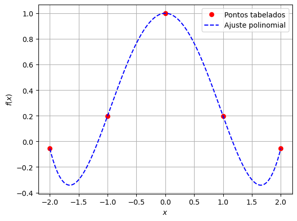

```python
n = 4
coeff = discretepolynfit(xk, fxk, n)
print(coeff)
fpolyn = lambda x: sum([coeff[i]*x**i for i in range(0,n+1)])

xrange = np.linspace(-2, 2, 300)
plt.plot(xk, fxk, "ro")
plt.plot(xrange, fpolyn(xrange), "b--")
plt.xlabel("$x$")
plt.ylabel("$f(x)$")
plt.grid()
plt.legend(["Pontos tabelados", "Ajuste polinomial"])
plt.show()
```

Ajustamos a função por um polinômio de modo que:

\begin{aligned} f(x) \approx 1.000 - 1.311 \times 10^{-17}x - 9.803 \times 10^{-1}x^2 + 3.855 \times 10^{-18}x^3 + 1.791 \times 10^{-1}x^4 \end{aligned}

## Resposta 2.2

```
[ 0.89795  0.      -0.69125 -0.       0.11454]
```

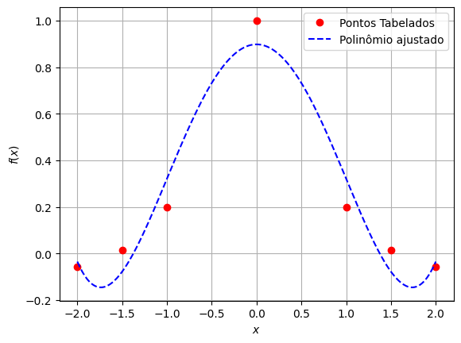

```python
xk2 = np.array([-2, -1.5, -1, 0, 1, 1.5, 2])
fxk2 = f(xk2)

coeff2 = discretepolynfit(xk2, fxk2, n)
print(coeff2)
fpolyn2 = lambda x: sum([coeff2[i]*x**i for i in range(0,n+1)])
plt.plot(xk2, fxk2, "ro")
plt.plot(xrange, fpolyn2(xrange), "b--")
plt.xlabel("$x$")
plt.ylabel("$f(x)$")
plt.grid()
plt.legend(["Pontos Tabelados", "Polinômio ajustado"])
plt.show()
```

Aproximamos a função de modo que:

\begin{aligned} f(x) \approx 0.898 - 0.691 x^2 + 0.115 x^4 \end{aligned}

Enquanto os pontos tabelados originais eram bem descritos por uma função de quarto grau, os segundos descrevem melhor a função (por ter mais pontos), porém já vemos que também não são bem descritos por uma função de quarto grau (talvez precisariam de um grau superior).

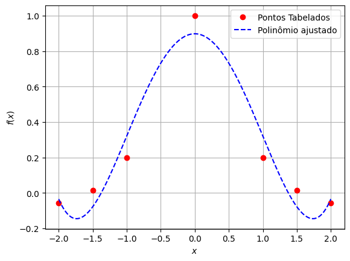

```python
n3 = 6

coeff3 = discretepolynfit(xk2, fxk2, n3)
fpolyn3 = lambda x: sum([coeff3[i]*x**i for i in range(0,n3+1)])
plt.plot(xk2, fxk2, "ro")
plt.plot(xrange, fpolyn2(xrange), "b--")
plt.xlabel("$x$")
plt.ylabel("$f(x)$")
plt.grid()
plt.legend(["Pontos Tabelados", "Polinômio ajustado"])
plt.show()
```

```python
#código feito para solução de edos
#não tem nenhum algorítmo explícito na apostila, mas utilizei o texto nela como base
def euler(f, x0, y0, h, n):
    #floor não funciona muito bem por causa de divisões estranhas de floats, ex: 0.3/0.1 = 2.9999999999999996
    x = np.zeros(n+1)
    y = np.zeros(n+1)
    x[0] = x0
    y[0] = y0
    for i in range(1,n+1):
        x[i] = x[i-1] + h
        y[i] = y[i-1] + h*f(x[i-1],y[i-1])
    i
    return (x,y)

def heun(f, x0, y0, h, n):
    x = np.zeros(n+1)
    y = np.zeros(n+1)
    x[0] = x0
    y[0] = y0
    for i in range(1,n+1):
        K1 = f(x[i-1], y[i-1])
        K2 = f(x[i-1] + h/3.0, y[i-1] + h*K1/3.0)
        K3 = f(x[i-1] + 2.0*h/3.0, y[i-1] + 2.0*h*K2/3.0)
        y[i] = y[i-1] + h*(K1 + 3.0*K3)/4.0
        x[i] = x[i-1] + h

    return (x,y)

#é facilmente generalizado para sistemas de equações diferenciais
def rk4(f, x0, y0, h, n):
    x = np.zeros(n+1)
    y = np.zeros(n+1)
    x[0] = x0
    y[0] = y0
    for i in range(1,n+1):
        K1 = f(x[i-1], y[i-1])
        K2 = f(x[i-1] + h/2.0, y[i-1] + h*K1/2.0)
        K3 = f(x[i-1] + h/2.0, y[i-1] + h*K2/2.0)
        K4 = f(x[i-1] + h, y[i-1] + h*K3)
        y[i] = y[i-1] + h*(K1 + 2.0*K2 + 2.0*K3 + K4)/6.0
        x[i] = x[i-1] + h

    return (x,y)
```

## Resposta 3

Tem solução em série de potências truncada com simpy.

```
-3.0 - 0.75*(x - 1)**2 + 1.375*(x - 1)**3 - 2.890625*(x - 1)**4 + 6.5859375*(x - 1)**5 - 15.826171875*(x - 1)**6 + 39.5006975446429*(x - 1)**7 + 5.0*x + O(x**8)
```

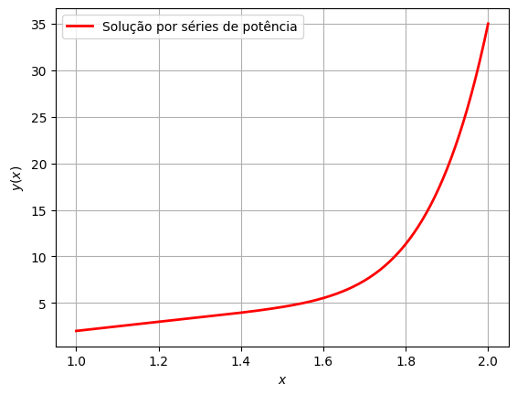

```python
from sympy import dsolve, Function, pprint, sin, cos, N
from sympy.abc import x
import sympy.plotting as splt

y = Function("y")
eq = -2.0*y(x).diff(x, 1) + 8.0 +4.0*x/y(x)
ysol = dsolve(eq, hint="1st_power_series", ics={y(1): 2}, n=8).rhs
print(ysol)

ysoln = lambda x: -3.0 - 0.75*(x - 1)**2 + 1.375*(x - 1)**3 - 2.890625*(x - 1)**4 + 6.5859375*(x - 1)**5 - 15.826171875*(x - 1)**6 + 39.5006975446429*(x - 1)**7 + 5.0*x
xrange = np.linspace(1, 2, 300)
plt.plot(xrange, ysoln(xrange), "r-", lw=2)
plt.xlabel("$x$")
plt.ylabel("$y(x)$")
plt.grid()
plt.legend(["Solução por séries de potência"])
plt.show()
```

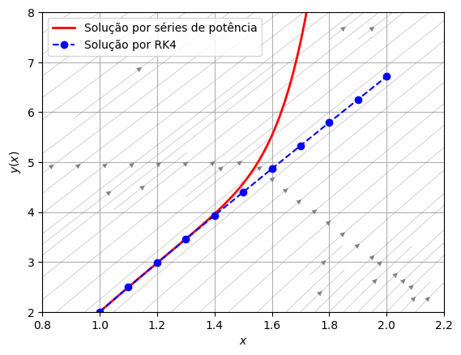

```python
df = lambda x,y: 4.0 + 2.0*x/y
x0 = 1.0
fx0 = 2.0
h = 0.1
n = 10
xsol,ysol = rk4(df, x0, fx0, h, n)

xmesh = np.linspace(0.0, 2.2, 100)
ymesh = np.linspace(2, 8, 100)

Xl, Yl = np.meshgrid(xmesh, ymesh)
P = Xl/Xl
Q = 4.0 +2.0*Xl/(Yl)

plt.plot(xrange, ysoln(xrange), "r-", lw=2)
plt.plot(xsol, ysol, "bo--")

plt.streamplot(Xl, Yl, P, Q, density=1.5, color="gray", linewidth=0.25)

plt.xlabel("$x$")
plt.ylabel("$y(x)$")
plt.xlim(0.8, 2.2)
plt.ylim(2, 8)
plt.grid()
plt.legend(["Solução por séries de potência", "Solução por RK4"])
plt.show()
```

Temos uma aproximação boa em série de potência somente na região perto de 1, que foi onde a solução é expandida em série de potência, enquanto a solução numérica se aproxima bem da solução real.